# 123190075_Tugas1

Yohanes Ageng Hendrawan Zhamudra Putra

9/19/2022

##MODUL 3

```r
library(dslabs)
data(murders)
```

1. Gunakan fungsi str untuk memeriksa struktur objek “murders”. Manakah dari pernyataan berikut ini yang paling menggambarkan karakter dari tiap variabel pada data frame?
1. Terdiri dari 51 negara.
2. Data berisi tingkat pembunuhan pada 50 negara bagian dan DC.
3. Data berisi Nama negara bagian, singkatan dari nama negara bagian, wilayah negara bagian, dan populasi negara bagian serta jumlah total pembunuhan pada tahun 2010.
4. str tidak menunjukkan informasi yang relevan.

```r
str(murders)
```

```
## 'data.frame':    51 obs. of  5 variables:
##  $ state     : chr  "Alabama" "Alaska" "Arizona" "Arkansas" ...
##  $ abb       : chr  "AL" "AK" "AZ" "AR" ...
##  $ region    : Factor w/ 4 levels "Northeast","South",..: 2 4 4 2 4 4 1 2 2 2 ...
##  $ population: num  4779736 710231 6392017 2915918 37253956 ...
##  $ total     : num  135 19 232 93 1257 ...
```

Pilihan C merupakan pernyataan paling menggambarkan tiap variabel

2. Sebutkan apa saja nama kolom yang digunakan pada data frame names(murders)

```r
names(murders)
```

```
## [1] "state"      "abb"        "region"     "population" "total"
```

3. Gunakan operator aksesor ($) untuk mengekstrak informasi singkatan negara dan menyimpannya pada objek “a”. Sebutkan jenis class dari objek tersebut.

```r
a = murders$abb
class(a)
```

```
## [1] "character"
```

4. Gunakan tanda kurung siku untuk mengekstrak singkatan negara dan menyimpannya pada objek “b”. Tentukan apakah variabel “a” dan “b” bernilai sama?

```r
b = murders['abb']
print(a)
```

```
##  [1] "AL" "AK" "AZ" "AR" "CA" "CO" "CT" "DE" "DC" "FL" "GA" "HI" "ID" "IL" "IN"
## [16] "IA" "KS" "KY" "LA" "ME" "MD" "MA" "MI" "MN" "MS" "MO" "MT" "NE" "NV" "NH"
## [31] "NJ" "NM" "NY" "NC" "ND" "OH" "OK" "OR" "PA" "RI" "SC" "SD" "TN" "TX" "UT"
## [46] "VT" "VA" "WA" "WV" "WI" "WY"
```

```r
print(b)
```

```
##    abb
## 1   AL
## 2   AK
## 3   AZ
## 4   AR
## 5   CA
## 6   CO
## 7   CT
## 8   DE
## 9   DC
## 10  FL
## 11  GA
## 12  HI
## 13  ID
## 14  IL
```

[output cut: 37 more lines]

5. Variabel region memiliki tipe data: factor. Dengan satu baris kode, gunakan fungsi level dan length untuk menentukan jumlah region yang dimiliki dataset.

```r
region = murders$region
levels(region)
```

```
## [1] "Northeast"     "South"         "North Central" "West"
```

```r
length(levels(region))
```

```
## [1] 4
```

6. Fungsi table dapat digunakan untuk ekstraksi data pada tipe vektor dan menampilkan frekuensi dari setiap elemen. Dengan menerapkan fungsi tersebut, dapat diketahui jumlah state pada tiap region. Gunakan fungsi table dalam satu baris kode untuk menampilkan tabel baru yang berisi jumlah state pada tiap region.

```r
table(region)
```

```
## region
##     Northeast         South North Central          West
##             9            17            12            13
```

##MODUL 4

1. Gunakan operator aksesor ($) untuk mengakses variabel populasi dan menyimpannya pada objek baru “pop”. Kemudian gunakan fungsi sort untuk mengurutkan variabel “pop”. Pada langkah terakhir, gunakan operator ([) untuk menampilkan nilai populasi terkecil.

```r
pop = murders$population
asc = sort(pop)
asc [1]
```

```
## [1] 563626
```

```r
min(pop)
```

```
## [1] 563626
```

2. Tampilkan indeks dari data yang memiliki nilai populasi terkecil. Petunjuk: gunakan fungsi order.

```r
x = murders$population
index = order(x)
index[1]
```

```
## [1] 51
```

3. Dengan fungsi which.min, Tulis satu baris kode yang dapat menampilkan hasil yang sama dengan langkah diatas.

```r
which.min(murders$population)
```

```
## [1] 51
```

4. Tampilkan nama negara yang memiliki populasi terkecil.

```r
q = murders$population
p = order(q)
m = p[1]
s = murders$state
s[m]
```

```
## [1] "Wyoming"
```

5. Gunakan fungsi rank untuk menentukan peringkat populasi dari tiap negara bagian, dimulai dari nilai terkecil hingga terbesar. Simpan hasil pemeringkatan di objek baru “ranks”, lalu buat data frame baru yang berisi nama negara bagian dan peringkatnya dengan nama “my_df”.

```r
temp = c(35, 88, 42, 84, 81, 30)
city = c("Beijing", "Lagos", "Paris", "Rio de Janeiro",
 "San Juan", "Toronto")
city_temps = data.frame(name = city, temperature = temp)
rank(city_temps$temperature)
```

```
## [1] 2 6 3 5 4 1
```

```r
my_df = city_temps[order(rank(city_temps$temperature)),]
my_df
```

```
##             name temperature
## 6        Toronto          30
## 1        Beijing          35
## 3          Paris          42
## 5       San Juan          81
## 4 Rio de Janeiro          84
## 2          Lagos          88
```

6. Ulangi langkah sebelumnya, namun kali ini urutkan my_df dengan fungsi order agar data yang ditampilkan merupakan data yang telah diurutkan dari populasi yang paling tidak padat hingga ke yang terpadat. Petunjuk: buat objek “ind” yang akan menyimpan indeks yang diperlukan dalam mengurutkan data populasi

```r
ind = rank(murders$populations)
my_Df = murders[order(rank(murders$population)),]
my_Df
```

```
##                   state abb        region population total
## 51              Wyoming  WY          West     563626     5
## 9  District of Columbia  DC         South     601723    99
## 46              Vermont  VT     Northeast     625741     2
## 35         North Dakota  ND North Central     672591     4
## 2                Alaska  AK          West     710231    19
## 42         South Dakota  SD North Central     814180     8
## 8              Delaware  DE         South     897934    38
## 27              Montana  MT          West     989415    12
## 40         Rhode Island  RI     Northeast    1052567    16
## 30        New Hampshire  NH     Northeast    1316470     5
## 20                Maine  ME     Northeast    1328361    11
## 12               Hawaii  HI          West    1360301     7
## 13                Idaho  ID          West    1567582    12
## 28             Nebraska  NE North Central    1826341    32
```

[output cut: 37 more lines]

7. Untuk keperluan analisis data, akan dibuat plot yang memvisualisasikan total pembunuhan terhadap populasi dan mengidentifikasi hubungan antara keduanya

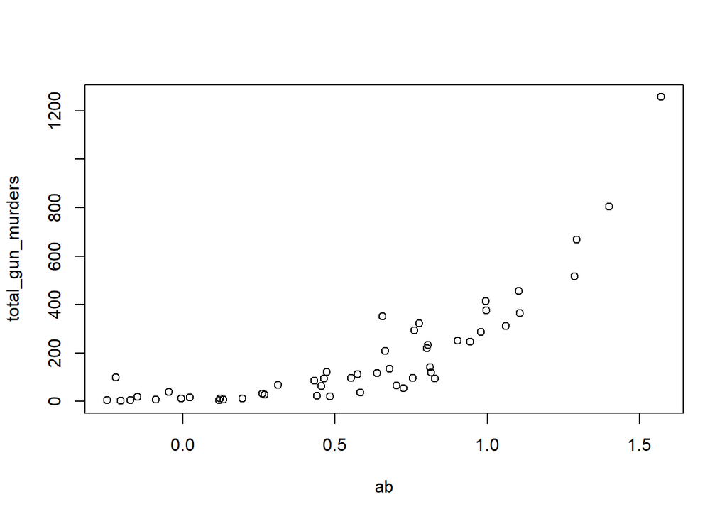

```r
population_in_millions = murders$population/10^6
total_gun_murders = murders$total
ab = log10(population_in_millions)
plot(ab, total_gun_murders)
```

Buat histogram dari populasi negara bagian.

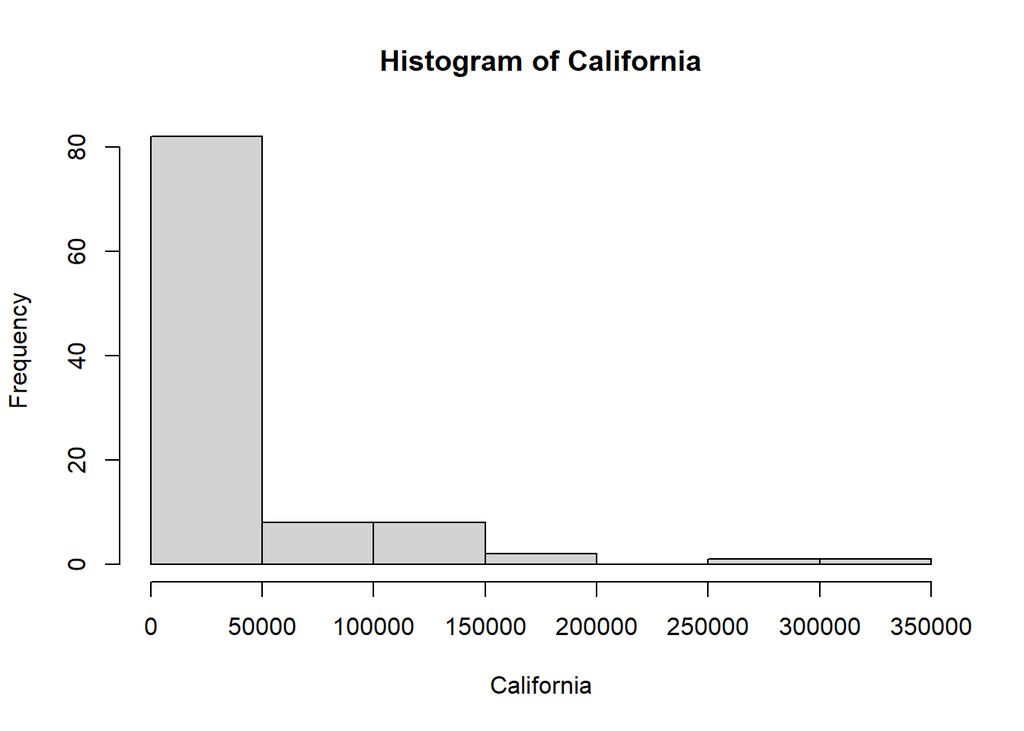

```r
Populasi = log10(murders$population)
California = c(Populasi, murders$population/murders$total)
hist(California)
```

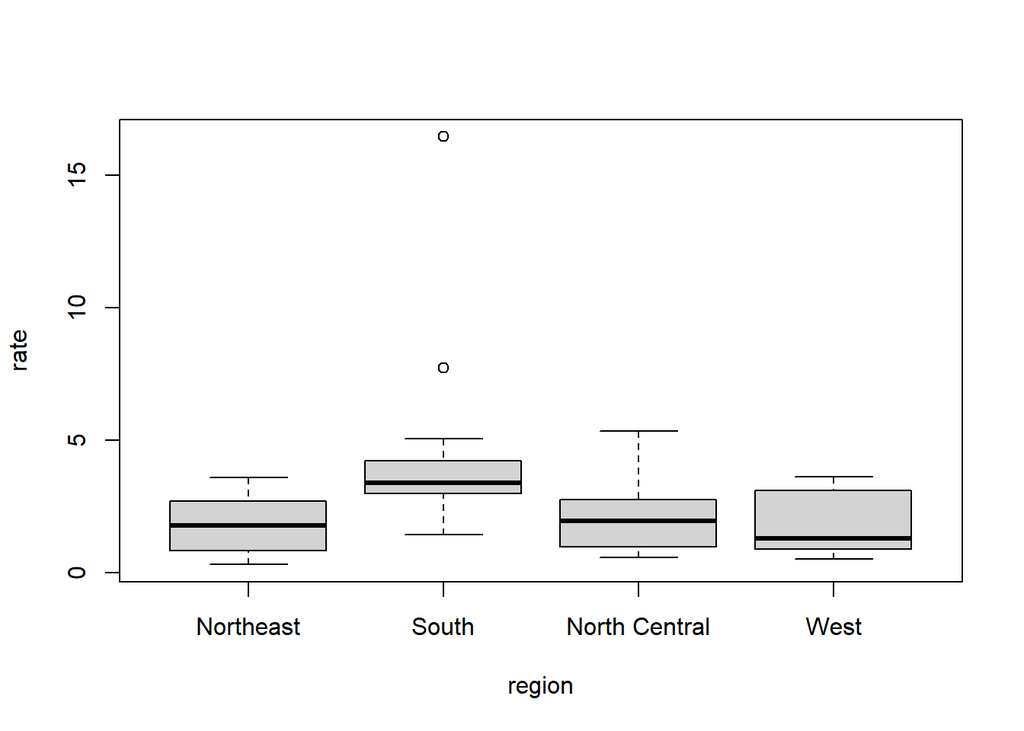

```r
murders$rate = with(murders, total / population * 100000)
boxplot(rate~region, data = murders)
```